# Project 1 Final Report

Authors

Ian Cay

Drew Cloughley

Nico Ragasa

# Context of The Data

## *Geopolitics: Government Types*

The primary dataset *Democracy and Dictatorship* was collected by Jon Harmon, and published for *tidytuesday* on GitHub. Data was collected on each global country from 1950-2020, and each observation corresponds to a single country for an individual year. Harmon collected the data in 2024, and published it to *tidytuesday* on November 5, 2024. The dataset contains information from 1950 to 2020. Harmon obtained the data from databases created by Christian Bjørnskov and Martin Rode in 2020. The original article *Regime types and regime change: A new dataset on democracy, coups, and political institutions* by Bjørnskov and Rode was published on February 4, 2019. This data allows us to compare political ideologies, leader information, important dates, and government systems across global countries from 1950 to 2020, however our analyze focuses in on 2020 to analyze new, associated variables. We added a variable *continent* to represent each country’s respective continent by grouping country codes within each continent.

## *Country Population Data*

The data for country populations in 2020 was webscraped from Wikipedia page *List of countries and dependencies by population* (https://en.wikipedia.org/wiki/List_of_countries_and_dependencies_by_population). Information about who collected the data is not disclosed, but original statistics were obtained from the United Nations and the United Nations Department of Economic and Social Affairs. Population statistics were collected for each global country, and each observation is a single country. The complete dataset was contains data collected from 2020 to 2026. Due to 2020 population statistics not being available for all countries, we obtained the closest value to reflect the 2020-era population. The data originated from the United Nations Department of Economic and Social Affairs, and published into the Wikipedia article mentioned. We used web scraping to take values from the first table on the page, and extract each country and their respective population value. This information was stored in a temporary R data frame before being appended to our meta dataset for 2020 using each countries ISO alpha-3 code. Knowing population statistics across global countries allows us to analyze the association of larger numbers of country inhabitants with a country’s political system.

## *Country GDP Data*

The data for country GDP was obtained through an API request to *API Ninjas*. Details about who collected the data is not provided, but the *API Ninjas* sourced their statistics from the *World Bank*. Information was collected on every country globally, and each observation is a single country. The data contains GDP statistics dating back to 1980, however the publication date of the API dataset is not listed. We retrieved values of country GDP through a function with an API request for an inputted country with the query parameter of *year* set to 2020. The function outputted the country’s nominal GDP in billions in US dollars. Each request used a personal, hidden key, and the function was iterated over every country in our data, stored in a temporary R data frame, and appended to our meta dataset for 2020 using each countries ISO alpha-3 code. GDP statistics allows us observe whether there is a connection between a country’s economic strength and political structure.

## Data Set Up, Retrieval, and Construction

### 1. Gathering the *Democracy and Dictatorship* dataset:

```r
library(tidyverse)
library(ggplot2)
library(ggridges)
library(lmtest)
library(knitr)
library(httr)
library(jsonlite)
library(tidyjson)
library(gt)
library(countrycode)

democracy_data <- readr::read_csv('https://raw.githubusercontent.com/rfordatascience/tidytuesday/main/data/2024/2024-11-05/democracy_data.csv')
```

### 2. Assigning continent names to each country and filtering out non-countries:

```r
democracy_data <- democracy_data |>
  mutate(
    continent = case_when(

      country_code %in% c(
        "DZA","AGO","BEN","BWA","BFA","BDI","CMR","CPV","CAF","TCD","COM","COG","COD",
        "CIV","DJI","EGY","GNQ","ERI","SWZ","ETH","GAB","GMB","GHA","GIN","GNB","KEN",
        "LSO","LBR","LBY","MDG","MWI","MLI","MRT","MUS","MAR","MOZ","NAM","NER","NGA",
        "RWA","STP","SEN","SYC","SLE","SOM","ZAF","SSD","SDN","TZA","TGO","TUN","UGA",
        "ZMB","ZWE","ZAR"
      ) ~ "Africa",

      # North America (incl. Caribbean)
      country_code %in% c(
        "CAN","USA","MEX","BHS","BRB","CUB","DMA","DOM","GRD","HTI","JAM",
        "KNA","LCA","VCT","TTO","ATG"
      ) ~ "North America",

      # Central America
      country_code %in% c(
        "BLZ","CRI","SLV","GTM","HND","NIC","PAN"
      ) ~ "Central America",

      # South America
      country_code %in% c(
        "ARG","BOL","BRA","CHL","COL","ECU","GUY","PRY","PER","SUR","URY","VEN"
      ) ~ "South America",

      country_code %in% c(
        "AFG","ARM","AZE","BHR","BGD","BTN","BRN","KHM","CHN","CYP","GEO","IND","IDN",
        "IRN","IRQ","ISR","JPN","JOR","KAZ","KWT","KGZ","LAO","LBN","MYS","MDV","MNG",
        "MMR","NPL","PRK","OMN","PAK","PSE","PHL","QAT","SAU","SGP","KOR","LKA","SYR",
        "TWN","TJK","THA","TLS","TUR","TKM","ARE","UZB","VNM","YEM"
      ) ~ "Asia",

      country_code %in% c(
        "ALB","AND","AUT","BLR","BEL","BIH","BGR","HRV","CYP","CZE","DNK","EST","FIN",
        "FRA","DEU","GRC","HUN","ISL","IRL","ITA","LVA","LIE","LTU","LUX","MLT","MDA",
        "MCO","MNE","NLD","MKD","NOR","POL","PRT","ROU","RUS","SMR","SRB","SVK","SVN",
        "ESP","SWE","CHE","UKR","GBR","VAT","GER","ROM"
      ) ~ "Europe",

      country_code %in% c(
        "AUS","FJI","KIR","MHL","FSM","NRU","NZL","PLW","PNG","WSM","SLB","TON","TUV",
        "VUT","NUR"
      ) ~ "Oceania",

      TRUE ~ NA_character_
    )
  ) |>
  filter(!is.na(continent))
```

### 3. Web scraping population statistics:

```r
library(rvest)

populations <- read_html("https://en.wikipedia.org/wiki/List_of_countries_and_dependencies_by_population")

pop_data <- populations |>
  html_element("table.wikitable") |>
  html_table(fill = TRUE) |>
  select(
    Country = 1,
    Population = 2
    ) |>
  mutate(
    Country    = trimws(Country),
    Population = as.numeric(gsub("[^0-9]", "", Population))  # strip anything that isn't a digit
  ) |>
  filter(!is.na(Population))
```

### 4. Creating a temporary 2020 Country Population data frame:

```r
pop_data <- pop_data |>
  mutate(
    iso3c = countrycode(Country,
                        origin = "country.name",
                        destination = "iso3c"
                        ))

democracy_data_2020 <- democracy_data |>
  filter(year == 2020) |>
  mutate(
    iso3c = countrycode(country_name,
                        origin = "country.name",
                        destination = "iso3c"
                        ))

# Now join based on iso3c country code
country_data <- pop_data |>
  inner_join(democracy_data_2020,
             by = "iso3c")
```

### 5. API request for GDP in USD in billions:

```r
# Obtain 2020 GDP in USD for inputted country
get_gdp_2020 <- function(country, key = my_key)
  {

  # Store url to access API with country and key queries
  url <- glue("https://api.api-ninjas.com/v1/gdp?year=2020;country={country};X-Api-Key={key}")

  # Temporarily store JSON data safely
  my_data <- safely(fromJSON)(url)

  # Check if JSON was successfully obtained
  if (is.null(my_data$result) |
      length(my_data$result) == 0) {
    return(NA)
  } else {
    return(my_data$result$gdp_nominal)
  }
}
```

### 6. Storing country GDPs in a temporary data frame and saving as a .csv file:

```r
# We used a personal API key stored as "my_key"

# Get GDP for all countries
gdps <- map_dbl(.x = country_data$iso3c, .f = get_gdp)

# Store GDP with country code as a tibble
country_gdps <- tibble(iso3c = country_data$iso3c, GDP = gdps)

# Save tibble as a csv
write.csv(country_gdps, file = "country_gdps.csv")
```

### 7. Create the meta dataset for all countries in 2020:

```r
# Read in csv GDP data
gdp_data <- read.csv("country_gdps.csv")
gdp_data <- gdp_data |>
  select(-X)

# Combine GDP with aggregate 2020 data
country_meta_data <- country_data |>
  inner_join(gdp_data,
             by = "iso3c",
             relationship = "many-to-many")
```

### 8. Adding the gov_type variable:

```r
country_meta_data <- country_meta_data |>
  mutate(gov_type = ifelse(is_communist == TRUE, "Communist",
                           ifelse(is_democracy == TRUE, "Democracy",
                                  ifelse(is_monarchy == TRUE, "Monarchy", "Other")))
         )

country_meta_data
```

```
# A tibble: 194 × 49
   Country       Population iso3c country_name  country_code  year
   <chr>              <dbl> <chr> <chr>         <chr>        <dbl>
 1 India         1417492000 IND   India         IND           2020
 2 China         1404890000 CHN   China         CHN           2020
 3 United States  341784857 USA   United States USA           2020
 4 Indonesia      288315089 IDN   Indonesia     IDN           2020
 5 Pakistan       241499431 PAK   Pakistan      PAK           2020
 6 Nigeria        223800000 NGA   Nigeria       NGA           2020
 7 Brazil         213421037 BRA   Brazil        BRA           2020
 8 Bangladesh     169828911 BGD   Bangladesh    BGD           2020
 9 Russia         146028325 RUS   Russia        RUS           2020
10 Mexico         131001723 MEX   Mexico        MEX           2020
# ℹ 184 more rows
# ℹ 43 more variables: regime_category_index <dbl>, regime_category <chr>,
#   is_monarchy <lgl>, is_commonwealth <lgl>, monarch_name <chr>,
#   monarch_accession_year <dbl>, monarch_birthyear <dbl>,
#   is_female_monarch <lgl>, is_democracy <lgl>, is_presidential <lgl>,
#   president_name <chr>, president_accesion_year <dbl>,
#   president_birthyear <dbl>, is_interim_phase <lgl>, …
```

# Defining our Functions

### Ridgeline Plots for the Relationship Between Categorical Variables and GDP in USD (in Billions)

```r
plot_gdp_by_category <- function(cat_var) {
  # Store variable names
  var_name <- deparse(substitute(cat_var))
  var_name2 <- recode(var_name,
                      "regime_category" = "Regime Category",
                      "gov_type" = "Government Type",
                      .default = var_name)

  country_meta_data |>
    filter(!is.na({{ cat_var }})) |>
    ggplot(aes(y = {{ cat_var }}, x = GDP, fill = {{ cat_var }})) +
    geom_density_ridges(alpha = 0.5) +
    scale_fill_viridis_d() +
    scale_x_log10(labels = scales::comma) +
    labs(
      x     = "GDP (log scale)",
      y     = "",
      title = paste("Country GDP in USD (in Billions) by", var_name2),
      subtitle = paste("Comparing the GDP of Countries by", var_name2)
    ) +
    theme_bw() +
    theme(legend.position = "none",
          panel.grid.minor = element_blank(),
          text = element_text(family = "Helvetica", size = 12))

}
```

### Summary Statistics for the Relationship Between Categorical Variables and GDP in USD (in Billions)

```r
summarize_gdp_by_category <- function(cat_var) {

  # Store variable names for use inside gt()
  var_name <- deparse(substitute(cat_var))
  var_name2 <- recode(var_name,
                      "regime_category" = "Regime Category",
                      "gov_type" = "Government Type",
                      .default = var_name)

  country_meta_data |>
    filter(!is.na({{ cat_var }})
    ) |>
    group_by({{ cat_var }}) |>
    summarize(n = n(),
              mean_GDP = mean(GDP, na.rm = TRUE),
              med_GDP = median(GDP, na.rm = TRUE),
              sd_GDP = sd(GDP, na.rm = TRUE),
              se_GDP = sd_GDP / sqrt(n),
              min_gdp = min(GDP, na.rm = TRUE),
              max_gdp = max(GDP, na.rm = TRUE),
              .groups    = "drop"
    ) |>
    arrange(desc(mean_GDP)) |>
    gt() |>
    fmt_currency(columns = 3:8,
                 decimals = 2,
                 currency = "USD",
                 placement = "left",
                 pattern = "{x}B"
    ) |>
    tab_spanner(label = "Category Breakdown",
                columns = 1:2
    ) |>
    tab_spanner(label = "Midpoints",
                columns = 3:4
    ) |>
    tab_spanner(label = "Variation",
                columns = 5:6
    ) |>
    tab_spanner(label = "Range",
                columns = 7:8
    ) |>
    cols_label(!!var_name := var_name2,
               n = "Count",
               mean_GDP = "Mean",
               med_GDP = "Median",
               sd_GDP = "Standard Deviation",
               se_GDP = "Standard Error",
               min_gdp = "Minimum",
               max_gdp = "Maximum"
    ) |>
    data_color(method = "numeric",
               palette = "Blues"
    ) |>
    tab_header(title = paste("Table of GDP Statistics by", var_name2),
               subtitle = "(in USD in Billions)"
    ) |>
    tab_style(style = cell_text(weight = "bold"),
              locations = list(cells_title(groups = "title"),
                               cells_title(groups = "subtitle"),
                               cells_column_labels())
    ) |>
    tab_footnote(md("*Note 1*: Standard error was calculated as the standard deviation divided by the square root of the sample size.")) |>
    tab_footnote(md("*Note 2*: Darker blues represent greater values."))}
```

### Statistical Tests for Models Between Categorical Variables and GDP

```r
# Testing assumptions for model between log(GDP) and categorical variables
gdp_assumption_test <- function(cat_var) {

  var_name <- deparse(substitute(cat_var))
  model <- lm(reformulate(var_name, response = "log(GDP)"), data = country_meta_data)

  par(mfrow = c(2, 2))  # View all 4 diagnostic plots at once
  plot(model)

  print(shapiro.test(residuals(model)))   # testing normality assumption
  print(bptest(model))                    # testing equal variance assumption
  }
```

### Ridgeline Plots for the Relationship Between Categorical Variables and Population

```r
plot_pop_by_category <- function(cat_var) {

  # Store variable names
  var_name <- deparse(substitute(cat_var))
  var_name2 <- recode(var_name,
                      "regime_category" = "Regime Category",
                      "gov_type" = "Government Type",
                      .default = var_name)

  country_meta_data |>
    filter(!is.na({{ cat_var }})) |>
    ggplot(aes(y = {{ cat_var }}, x = Population, fill = {{ cat_var }})) +
    geom_density_ridges(alpha = 0.5) +
    scale_x_log10(labels = scales::comma) +
    scale_fill_viridis_d() +
    labs(
      x     = "Population (log scale)",
      y     = "",
      title = paste("Country Population by", var_name2),
      subtitle = paste("Comparing the Populations of Countries by", var_name2)
    ) +
    theme_bw() +
    theme(legend.position = "none",
          panel.grid.minor = element_blank(),
          text = element_text(family = "Helvetica", size = 12))
}
```

### Summary Statistics for the Relationship Between Categorical Variables and Population

```r
summarize_pop_by_category <- function(cat_var) {

  # Store variable names for use inside gt()
  var_name <- deparse(substitute(cat_var))
  var_name2 <- recode(var_name,
                      "regime_category" = "Regime Category",
                      "gov_type" = "Government Type",
                      .default = var_name)

  country_meta_data |>
    filter(!is.na({{ cat_var }})
    ) |>
    group_by({{ cat_var }}) |>
    summarize(n = n(),
              mean_pop = mean(Population, na.rm = TRUE),
              med_pop = median(Population, na.rm = TRUE),
              sd_pop = sd(Population, na.rm = TRUE),
              se_pop = sd_pop / sqrt(n),
              min_pop = min(Population, na.rm = TRUE),
              max_pop = max(Population, na.rm = TRUE),
              .groups    = "drop"
    ) |>
    arrange(desc(mean_pop)) |>
    gt() |>
    fmt_number(columns = 3:8,
                decimals = 2,
    ) |>
    tab_spanner(label = "Category Breakdown",
                columns = 1:2
    ) |>
    tab_spanner(label = "Midpoints",
                columns = 3:4
    ) |>
    tab_spanner(label = "Variation",
                columns = 5:6
    ) |>
    tab_spanner(label = "Range",
                columns = 7:8
    ) |>
    cols_label(!!var_name := var_name2,
               n = "Count",
               mean_pop = "Mean",
               med_pop = "Median",
               sd_pop = "Standard Deviation",
               se_pop = "Standard Error",
               min_pop = "Minimum",
               max_pop = "Maximum"
    ) |>
    data_color(method = "numeric",
               palette = "Blues"
    ) |>
    tab_header(title = paste("Table of Population Statistics by", var_name2)
    ) |>
    tab_style(style = cell_text(weight = "bold"),
              locations = list(cells_title(groups = "title"),
                               cells_title(groups = "subtitle"),
                               cells_column_labels())
    ) |>
    tab_footnote(md("*Note 1*: Standard error was calculated as the standard deviation divided by the square root of the sample size.")) |>
    tab_footnote(md("*Note 2*: Darker blues represent greater values."))
}
```

### Statistical Tests for Models Between Categorical Variables and Population

```r
# Testing assumptions for model between log(Population) and categorical variables
pop_assumption_test <- function(cat_var) {

  var_name <- deparse(substitute(cat_var))
  model <- lm(reformulate(var_name, response = "log(Population)"), data = country_meta_data)

  par(mfrow = c(2, 2))  # View all 4 diagnostic plots at once
  plot(model)

  print(shapiro.test(residuals(model)))   # testing normality assumption
  print(bptest(model))                    # testing equal variance assumption

  }
```

# Research Question 1: Are certain political ideologies more popular among higher/lower GDP countries?

## Ridgeline Plots for the Relationship Between Regime Category and GDP in USD (in Billions)

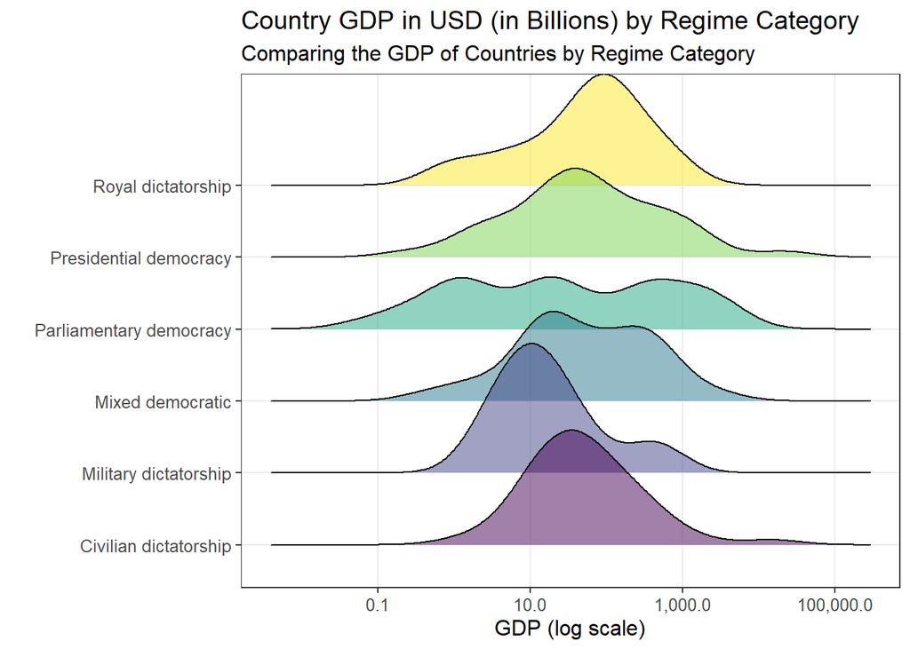

```r
plot_gdp_by_category(regime_category)
```

## Ridgeline Plots for the Relationship Between Communism, Democracy, and Monarchy Status and GDP in USD (in Billions)

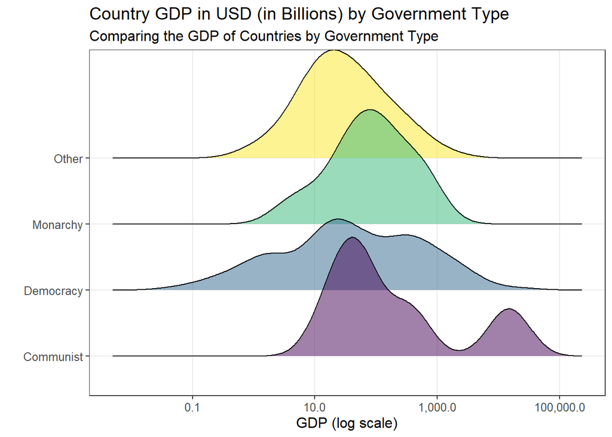

```r
plot_gdp_by_category(gov_type)
```

## Summary Statistics for the Relationship Between Regime Category and GDP in USD (in Billions)

```r
summarize_gdp_by_category(regime_category)
```

Table of GDP Statistics by Regime Category

(in USD in Billions)

| Category Breakdown Regime Category | Category Breakdown Count | Midpoints Mean | Midpoints Median | Variation Standard Deviation | Variation Standard Error | Range Minimum | Range Maximum |
| --- | --- | --- | --- | --- | --- | --- | --- |
| Presidential democracy | 39 | $776.25B | $53.67B | $3,407.98B | $545.71B | $0.26B | $21,354.12B |
| Parliamentary democracy | 50 | $521.67B | $22.33B | $1,076.21B | $152.20B | $0.05B | $5,054.09B |
| Civilian dictatorship | 48 | $445.74B | $43.24B | $2,186.81B | $315.64B | $1.22B | $14,862.56B |
| Mixed democratic | 28 | $233.52B | $55.11B | $509.92B | $96.37B | $0.48B | $2,645.81B |
| Royal dictatorship | 11 | $148.45B | $75.91B | $218.16B | $65.78B | $0.87B | $734.27B |
| Military dictatorship | 17 | $73.25B | $11.48B | $151.99B | $36.86B | $2.39B | $500.50B |

*Note 1*: Standard error was calculated as the standard deviation divided by the square root of the sample size.  
*Note 2*: Darker blues represent greater values.

## Summary Statistics for the Relationship Between Communism, Democracy, and Monarchy Status and GDP in USD (in Billions)

```r
summarize_gdp_by_category(gov_type)
```

Table of GDP Statistics by Government Type

(in USD in Billions)

| Category Breakdown Government Type | Category Breakdown Count | Midpoints Mean | Midpoints Median | Variation Standard Deviation | Variation Standard Error | Range Minimum | Range Maximum |
| --- | --- | --- | --- | --- | --- | --- | --- |
| Communist | 7 | $3,066.50B | $61.31B | $6,595.54B | $2,492.88B | $18.51B | $14,862.56B |
| Democracy | 117 | $537.85B | $34.36B | $2,110.18B | $195.09B | $0.05B | $21,354.12B |
| Monarchy | 12 | $180.62B | $93.48B | $229.34B | $66.20B | $3.98B | $734.27B |
| Other | 57 | $104.28B | $24.98B | $230.48B | $30.53B | $0.87B | $1,488.12B |

*Note 1*: Standard error was calculated as the standard deviation divided by the square root of the sample size.  
*Note 2*: Darker blues represent greater values.

## Statistical Test for Model Between Regime Category and GDP

### Model Assumptions

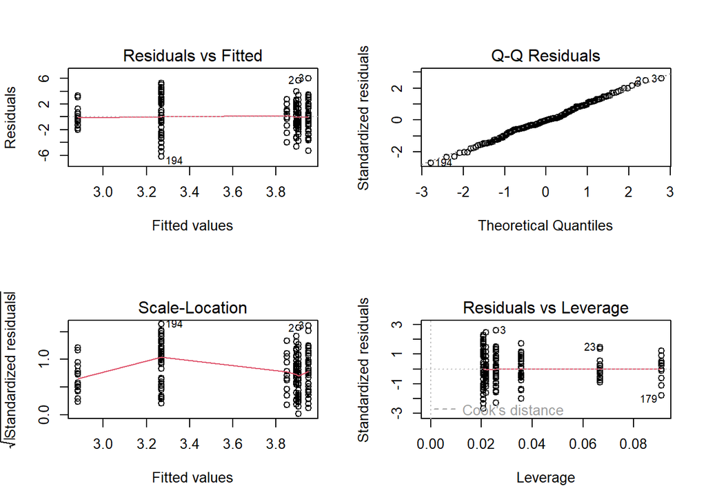

```
    Shapiro-Wilk normality test

data:  residuals(model)
W = 0.99479, p-value = 0.7619


    studentized Breusch-Pagan test

data:  model
BP = 27.864, df = 5, p-value = 3.87e-05
```

```r
gdp_assumption_test(regime_category)
```

For the regression model between Regime Category and log(GDP), the equal variance assumption was violated, but all of the other FINE assumptions were met.

### Significance Test

```r
# Welch's ANOVA
oneway.test(log(GDP) ~ regime_category, data = country_meta_data, var.equal = FALSE)
```

```
    One-way analysis of means (not assuming equal variances)

data:  log(GDP) and regime_category
F = 1.2188, num df = 5.00, denom df = 55.27, p-value = 0.3126
```

According to the Welch’s ANOVA (F = 1.2188; df = 5.00, 55.27; p-value = 0.31266), at an $\alpha = 0.05$ significance level, we do not have enough evidence that there is an association between the geometric mean GDP and the regime categories of countries.

## Statistical Tests for Models Between Communism, Democracy, and Monarchy Status and GDP

**Communism**

### Model Assumptions:

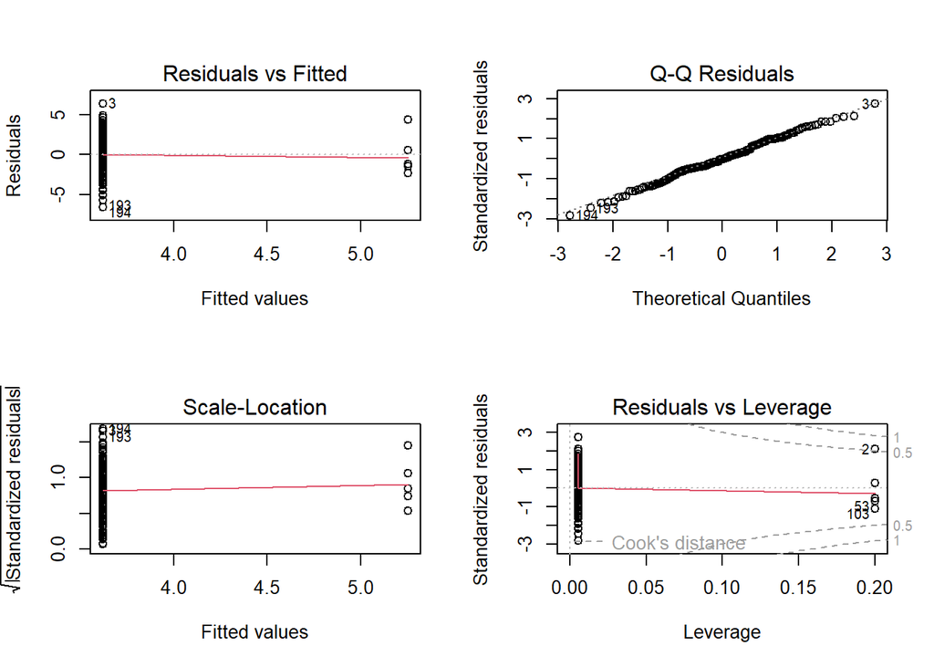

```
    Shapiro-Wilk normality test

data:  residuals(model)
W = 0.99513, p-value = 0.8074


    studentized Breusch-Pagan test

data:  model
BP = 0.0088159, df = 1, p-value = 0.9252
```

```r
gdp_assumption_test(is_communist)
```

For the regression model between Communist Status and log(GDP), all of the FINE assumptions were met.

### Significance Test:

```r
# Student's t-test
t.test(log(GDP) ~ is_communist, data = country_meta_data, var.equal = TRUE)
```

```
    Two Sample t-test

data:  log(GDP) by is_communist
t = -1.551, df = 185, p-value = 0.1226
alternative hypothesis: true difference in means between group FALSE and group TRUE is not equal to 0
95 percent confidence interval:
 -3.7123052  0.4444859
sample estimates:
mean in group FALSE  mean in group TRUE
           3.619617            5.253527
```

According to the Student’s two-sample t-test (t = -1.551; df = 185; p-value = 0.1226), at an $\alpha = 0.05$ significance level, we do not have enough evidence that there is an association between the geometric mean GDP and the communist status of countries.

**Democracy**

### Model Assumptions:

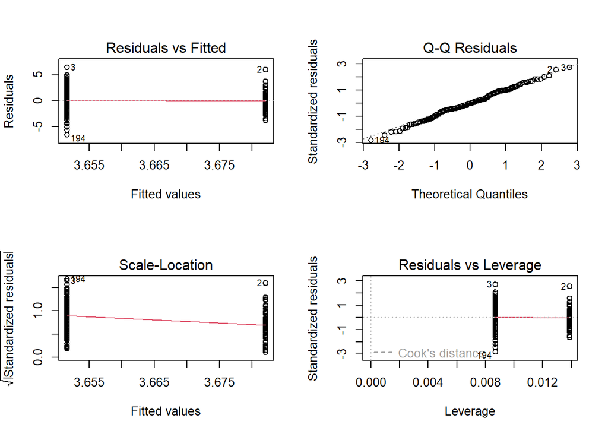

```
    Shapiro-Wilk normality test

data:  residuals(model)
W = 0.99541, p-value = 0.842


    studentized Breusch-Pagan test

data:  model
BP = 12.278, df = 1, p-value = 0.0004583
```

```r
gdp_assumption_test(is_democracy)
```

For the regression model between Democracy Status and log(GDP), the equal variance assumption was violated, but all of the other FINE assumptions were met.

### Significance Test:

```r
# Welch's t-test
t.test(log(GDP) ~ is_democracy, data = country_meta_data, var.equal = FALSE)
```

```
    Welch Two Sample t-test

data:  log(GDP) by is_democracy
t = 0.095288, df = 184.58, p-value = 0.9242
alternative hypothesis: true difference in means between group FALSE and group TRUE is not equal to 0
95 percent confidence interval:
 -0.6017095  0.6627823
sample estimates:
mean in group FALSE  mean in group TRUE
           3.682084            3.651548
```

According to the Welch’s two-sample t-test (t = 0.095288; df = 184.58; p-value = 0.9242), at an $\alpha = 0.05$ significance level, we do not have enough evidence that there is an association between the geometric mean GDP and the democracy status of countries.

**Monarchy**

### Model Assumptions:

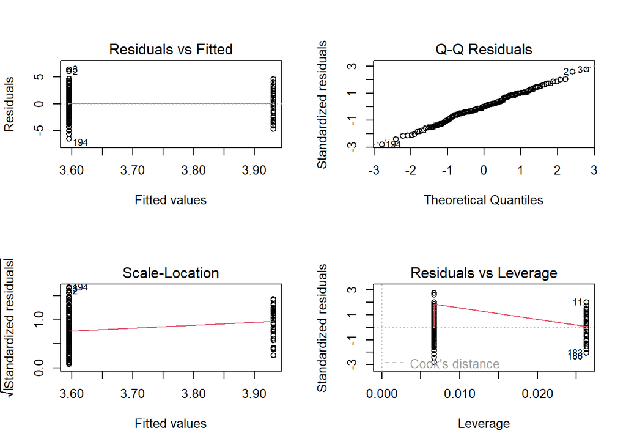

```
    Shapiro-Wilk normality test

data:  residuals(model)
W = 0.99438, p-value = 0.7054


    studentized Breusch-Pagan test

data:  model
BP = 1.9687, df = 1, p-value = 0.1606
```

```r
gdp_assumption_test(is_monarchy)
```

### Significance Test:

```r
# Student's t-test
t.test(log(GDP) ~ is_monarchy, data = country_meta_data, var.equal = TRUE)
```

```
    Two Sample t-test

data:  log(GDP) by is_monarchy
t = -0.792, df = 185, p-value = 0.4294
alternative hypothesis: true difference in means between group FALSE and group TRUE is not equal to 0
95 percent confidence interval:
 -1.1733021  0.5011171
sample estimates:
mean in group FALSE  mean in group TRUE
           3.595008            3.931101
```

According to the Student’s two-sample t-test (t = -0.792; df = 185; p-value = 0.4294), at an $\alpha = 0.05$ significance level, we do not have enough evidence that there is an association between the geometric mean GDP and the monarchy status of countries.

# Research Question 2: What is the association between the political ideologies and population of a country?

## Ridgeline Plots for the Relationship Between Regime Category and Population

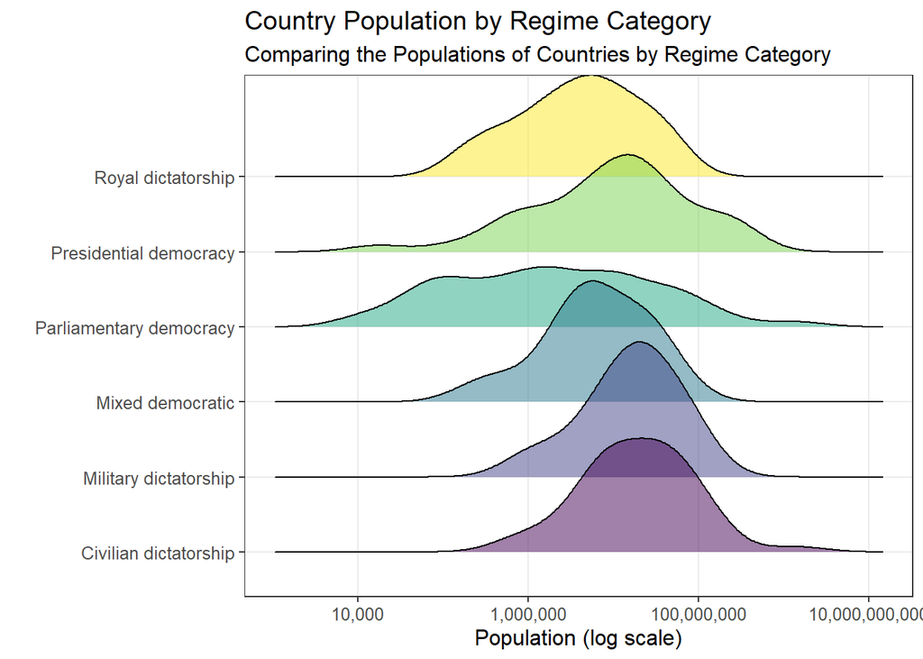

```r
plot_pop_by_category(regime_category)
```

## Ridgeline Plots for the Relationship Between Communism, Democracy, and Monarchy Status and Population

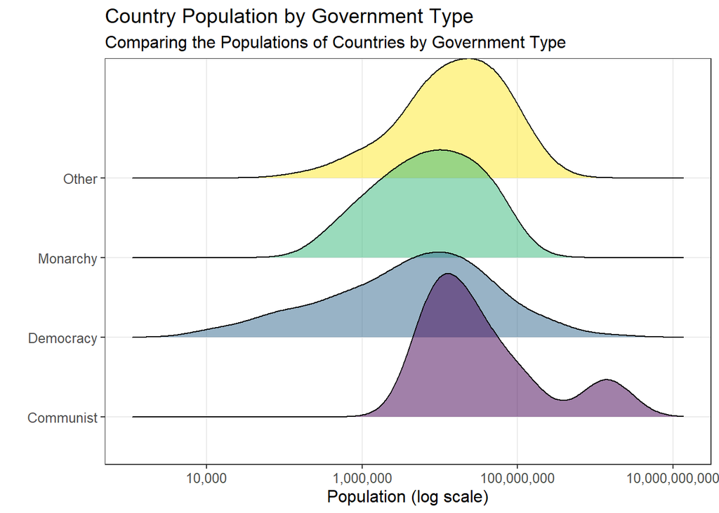

```r
plot_pop_by_category(gov_type)
```

## Summary Statistics for the Relationship Between Regime Category and Population

```r
summarize_pop_by_category(regime_category)
```

Table of Population Statistics by Regime Category

| Category Breakdown Regime Category | Category Breakdown Count | Midpoints Mean | Midpoints Median | Variation Standard Deviation | Variation Standard Error | Range Minimum | Range Maximum |
| --- | --- | --- | --- | --- | --- | --- | --- |
| Civilian dictatorship | 48 | 63,165,837.12 | 20,093,620.00 | 201,671,843.10 | 29,108,823.22 | 623,327.00 | 1,404,890,000.00 |
| Parliamentary democracy | 50 | 45,291,727.92 | 1,967,363.50 | 202,151,775.21 | 28,588,578.22 | 10,643.00 | 1,417,492,000.00 |
| Presidential democracy | 39 | 45,142,416.77 | 11,972,169.00 | 82,657,401.10 | 13,235,777.04 | 16,733.00 | 341,784,857.00 |
| Military dictatorship | 17 | 28,030,252.24 | 17,073,087.00 | 29,258,562.50 | 7,096,243.74 | 902,623.00 | 107,868,296.00 |
| Mixed democratic | 28 | 12,905,545.11 | 6,044,146.50 | 15,552,101.43 | 2,939,070.91 | 209,607.00 | 69,081,996.00 |
| Royal dictatorship | 11 | 10,210,745.09 | 4,881,254.00 | 13,390,049.36 | 4,037,251.79 | 205,557.00 | 36,828,330.00 |

*Note 1*: Standard error was calculated as the standard deviation divided by the square root of the sample size.  
*Note 2*: Darker blues represent greater values.

## Summary Statistics for the Relationship Between Communism, Democracy, and Monarchy Status and Population

```r
summarize_pop_by_category(gov_type)
```

Table of Population Statistics by Government Type

| Category Breakdown Government Type | Category Breakdown Count | Midpoints Mean | Midpoints Median | Variation Standard Deviation | Variation Standard Error | Range Minimum | Range Maximum |
| --- | --- | --- | --- | --- | --- | --- | --- |
| Communist | 7 | 226,872,583.86 | 25,950,000.00 | 520,513,392.65 | 196,735,570.15 | 7,647,000.00 | 1,404,890,000.00 |
| Democracy | 117 | 37,491,418.06 | 5,627,400.00 | 140,528,794.71 | 12,991,891.67 | 10,643.00 | 1,417,492,000.00 |
| Other | 57 | 32,231,018.09 | 17,073,087.00 | 37,884,458.35 | 5,017,919.09 | 205,557.00 | 169,828,911.00 |
| Monarchy | 12 | 16,293,045.67 | 8,331,181.50 | 19,991,461.65 | 5,771,037.88 | 458,600.00 | 65,826,149.00 |

*Note 1*: Standard error was calculated as the standard deviation divided by the square root of the sample size.  
*Note 2*: Darker blues represent greater values.

## Statistical Test for Model Between Regime Category and Population

### Model Assumptions

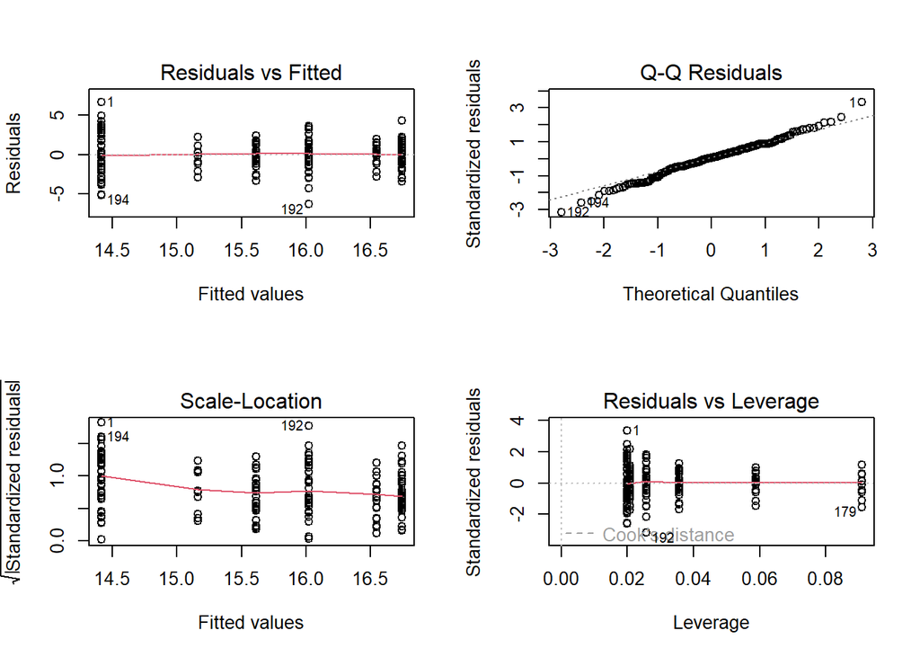

```
    Shapiro-Wilk normality test

data:  residuals(model)
W = 0.99181, p-value = 0.3489


    studentized Breusch-Pagan test

data:  model
BP = 25.083, df = 5, p-value = 0.0001343
```

```r
pop_assumption_test(regime_category)
```

For the regression model between Regime Category and log(Population), the equal variance assumption was violated, but all of the other FINE assumptions were met.

### Significance Test

```r
# Welch's ANOVA between regime_category and log(Population)
oneway.test(log(Population) ~ regime_category, data = country_data, var.equal = FALSE)
```

```
    One-way analysis of means (not assuming equal variances)

data:  log(Population) and regime_category
F = 6.9947, num df = 5.000, denom df = 57.656, p-value = 3.621e-05
```

According to the Welch’s ANOVA (F = 6.9947; df = 5, 57.656, p-value = 0.000036), at an $\alpha = 0.05$ significance level, we have extremely strong evidence that there is an association between the geometric mean population and the regime categories of countries.

## Statistical Tests for Models Between Communism, Democracy, and Monarchy Status and Population

**Communism**

### Model Assumptions:

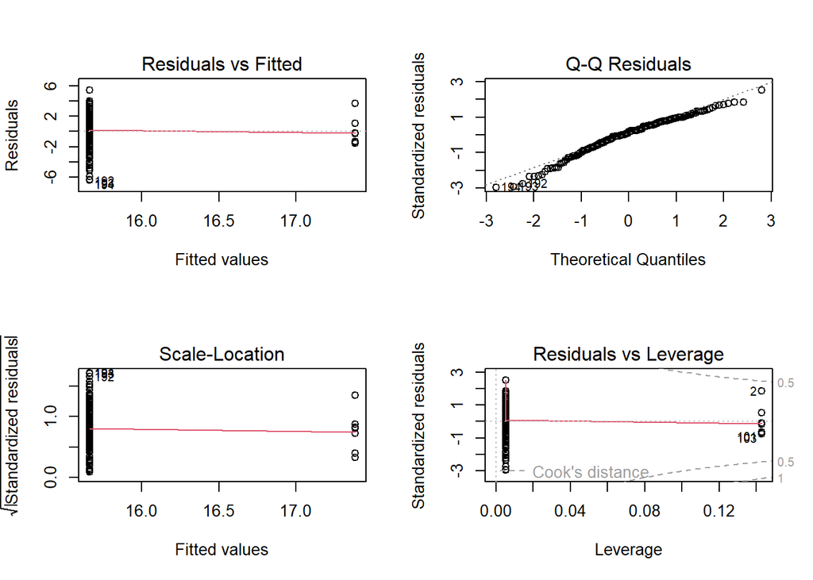

```
    Shapiro-Wilk normality test

data:  residuals(model)
W = 0.97387, p-value = 0.001132


    studentized Breusch-Pagan test

data:  model
BP = 0.42421, df = 1, p-value = 0.5148
```

```r
pop_assumption_test(is_communist)
```

For the regression model between Communist Status and log(Population), the normality assumption was violated, but all of the other FINE assumptions were met.

### Significance Test:

```r
# Mann-Whitney test between is_communist and log(Population)
wilcox.test(log(Population) ~ is_communist, data = country_data)
```

```
    Wilcoxon rank sum test with continuity correction

data:  log(Population) by is_communist
W = 399, p-value = 0.08853
alternative hypothesis: true location shift is not equal to 0
```

According to the Mann-Whitney test (W = 399; p-value = 0.08853), at an $\alpha = 0.05$ significance level, we have some evidence that there is an association between the geometric mean population and the communist status of countries.

**Democracy**

### Model Assumptions:

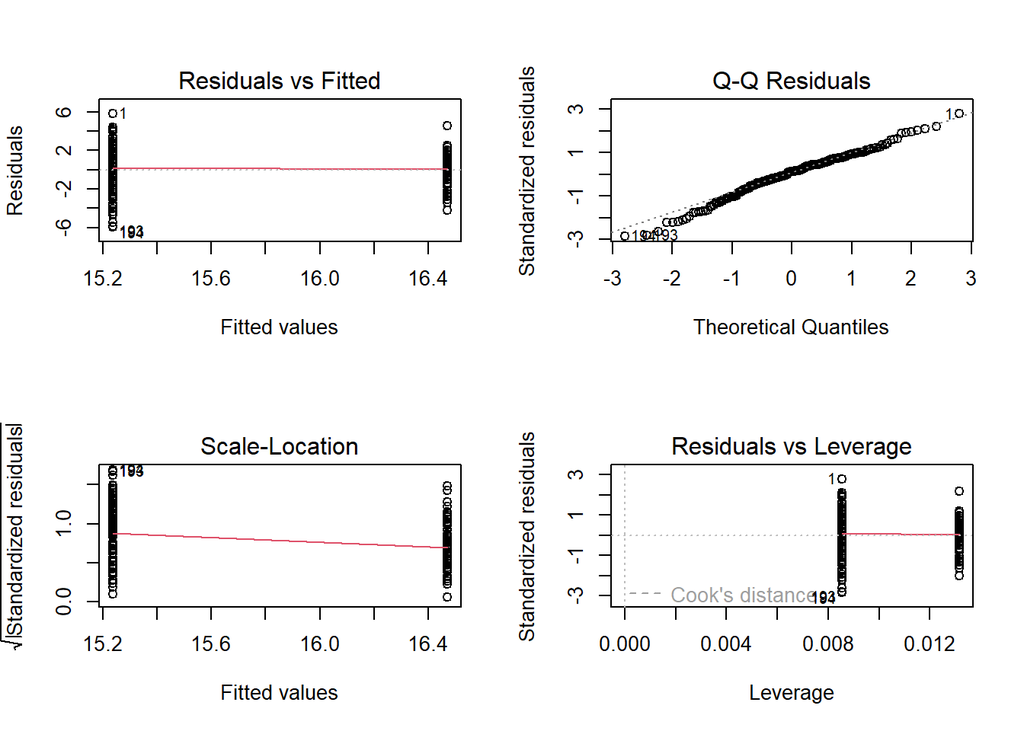

```
    Shapiro-Wilk normality test

data:  residuals(model)
W = 0.98585, p-value = 0.05002


    studentized Breusch-Pagan test

data:  model
BP = 11.803, df = 1, p-value = 0.0005914
```

```r
pop_assumption_test(is_democracy)
```

### Significance Test:

```r
# Welch's t-test between is_democracy and log(Population)
t.test(log(Population) ~ is_democracy, data = country_data, var.equal = FALSE)
```

```
    Welch Two Sample t-test

data:  log(Population) by is_democracy
t = 4.2001, df = 188.89, p-value = 4.108e-05
alternative hypothesis: true difference in means between group FALSE and group TRUE is not equal to 0
95 percent confidence interval:
 0.6371816 1.7657052
sample estimates:
mean in group FALSE  mean in group TRUE
           16.46952            15.26808
```

According to the Welch’s two-sample t-test (t = 4.2001; df = 188.89; p-value = 0.000041), at an $\alpha = 0.05$ significance level, we have extremely strong evidence that there is an association between the geometric mean population and the democracy status of countries.

**Monarchy**

### Model Assumptions:

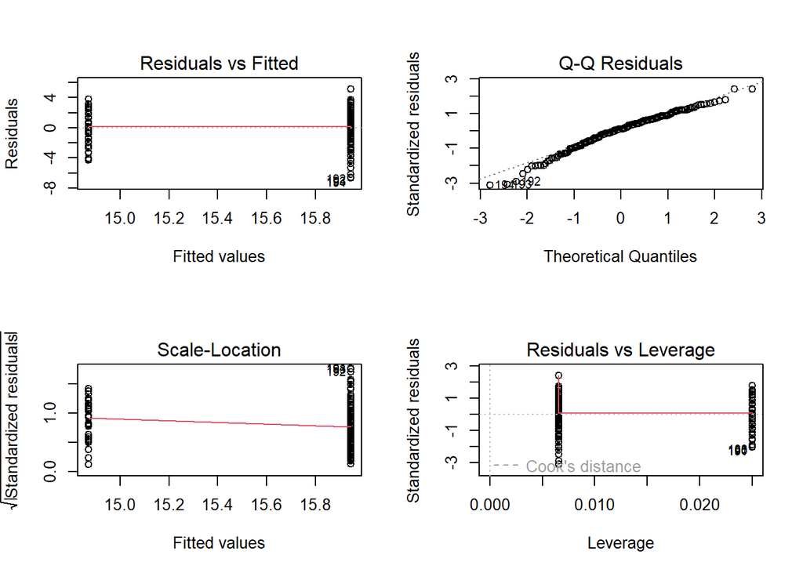

```
    Shapiro-Wilk normality test

data:  residuals(model)
W = 0.97712, p-value = 0.002995


    studentized Breusch-Pagan test

data:  model
BP = 0.41019, df = 1, p-value = 0.5219
```

```r
pop_assumption_test(is_monarchy)
```

For the regression model between Monarchy Status and log(Population), the normality assumption was violated, but all of the other FINE assumptions were met.

### Significance Test:

```r
# Mann-Whitney test between is_monarchy and log(Population)
wilcox.test(log(Population) ~ is_monarchy, data = country_data)
```

```
    Wilcoxon rank sum test with continuity correction

data:  log(Population) by is_monarchy
W = 3834, p-value = 0.008874
alternative hypothesis: true location shift is not equal to 0
```

According to the Mann-Whitney test (W = 3834; p-value = 0.008874), at an $\alpha = 0.05$ significance level, we have very strong evidence that there is an association between the geometric mean population and the monarchy status of countries.